# Reference_lm.R

colleenobriant

2023-04-08

```
               Intro to the Tidyverse by Colleen O'Briant
                        Reference Sheet: lm
```

This reference sheet will introduce you to the function `lm()`, which is used to use ordinary least squares to fit a linear regression in R. “lm” stands for “linear model”. There are *NO TESTS* and *NO EXERCISES* here: just read this over and reference back to it when you’re asked to run regressions in your problem sets.

```r
library(tidyverse)
students <- read_csv(
  "https://raw.githubusercontent.com/cobriant/students_dataset/main/students.csv",
  show_col_types = FALSE
) %>%
  mutate(
    study_time = factor(study_time, levels = c("less than 2H", "2 - 5H", "5 - 10H", "more than 10H")),
    alcohol = factor(alcohol, levels = c("very low", "moderately low", "medium", "moderately high", "very high"))
  )
```

`lm()` fits a linear model to a dataset using the method of least-squares. Read a little about how to use it here:

```r
?qelp::lm
```

# 1 `broom::tidy()`

Take the relationship between first-semester grades and final grades:

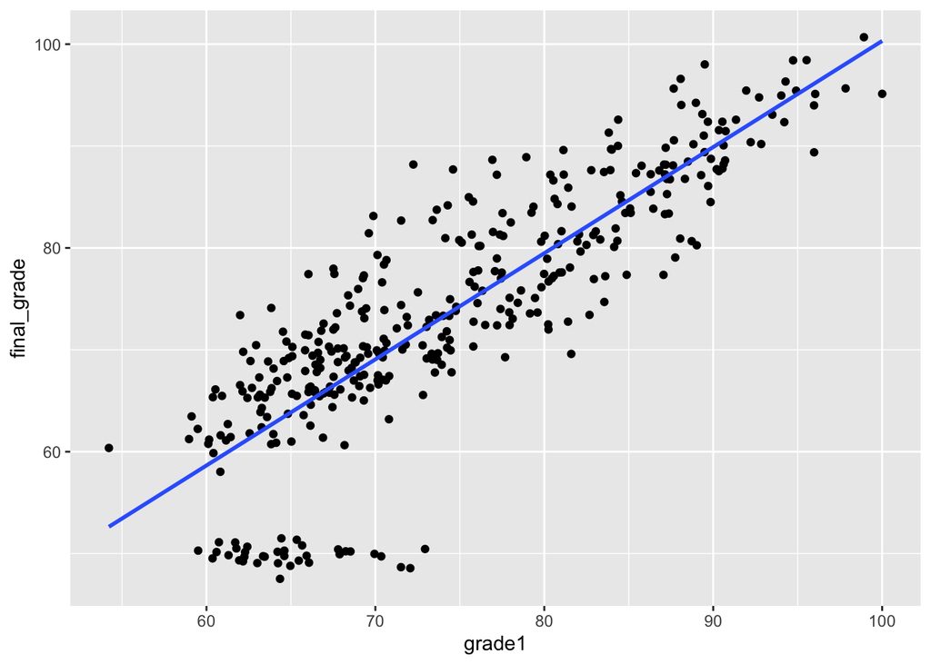

```r
students %>%
  ggplot(aes(x = grade1, y = final_grade)) +
  geom_point() +
  geom_smooth(method = "lm", se = FALSE)
```

The relationship looks very linear, so we might try linear regression to fit the model: $final grade_i = \beta_0 + \beta_1 grade1_i + u_i$ This is how to estimate this simple regression using `lm()`:

```r
students %>%
  lm(final_grade ~ grade1, data = .)
```

```
##
## Call:
## lm(formula = final_grade ~ grade1, data = .)
##
## Coefficients:
## (Intercept)       grade1
##      -3.861        1.042
```

`lm()` outputs a “lm object” which has a bunch of information in it but prints the bare minimum: the estimate for the intercept $\beta_0$ (-3.861) and the estimate for the slope $\beta_1$ (1.042). These are the “coefficients”. To access other useful information like standard errors and p-values, use `broom::tidy()`. Make sure to install the package `broom` by running this code:

```r
# install.packages("broom")
```

Then comment out or delete the previous line: you can’t compile a document which contains code where you install a package. Here’s me taking the code above and piping the lm object into `broom::tidy()` to get a “tidied” (organized in a tibble) version of the regression output.

```r
students %>%
  lm(final_grade ~ grade1, data = .) %>%
  broom::tidy()
```

```
## # A tibble: 2 × 5
##   term        estimate std.error statistic   p.value
##   <chr>          <dbl>     <dbl>     <dbl>     <dbl>
## 1 (Intercept)    -3.86    2.59       -1.49 1.37e-  1
## 2 grade1          1.04    0.0345     30.2  3.98e-102
```

The standard errors, statistic, and p.value tell us in three different ways how confident we can be in the estimates for the intercept and the slope.

# 2 R-squared

`broom` has another function for accessing data about lm objects: it’s `broom::glance()`. This is useful especially for accessing the R-squared for a regression, which you’ll learn about a little later in the class.

```r
students %>%
  lm(final_grade ~ grade1, data = .) %>%
  broom::glance()
```

```
## # A tibble: 1 × 12
##   r.squared adj.r.squared sigma statistic   p.value    df logLik   AIC   BIC
##       <dbl>         <dbl> <dbl>     <dbl>     <dbl> <dbl>  <dbl> <dbl> <dbl>
## 1     0.710         0.710  6.50      912. 3.98e-102     1 -1230. 2466. 2478.
## # ℹ 3 more variables: deviance <dbl>, df.residual <int>, nobs <int>
```

# 3 Fitted values and Residuals

The last thing you’ll be asked to do in this class is to find the fitted values and the residuals for a regression. There are two handy functions with memorable names that I prefer for this task: `fitted.values()` and `residuals()`:

```r
students %>%
  lm(final_grade ~ grade1, data = .) %>%
  fitted.values()

students %>%
  lm(final_grade ~ grade1, data = .) %>%
  residuals()
```

[output not shown]